# Web Mining and Applied NLP (44-620)

## Matplotlib and pyplot

### Student Name: Brett Neely

#### GitHub Link: https://github.com/bncodes19/pyplot

#### Intro: Tasks are performed sequentially in this notebook as part of coursework through Northwest Missouri State University's Data Analytics program.

```python
from collections import Counter
import matplotlib.pyplot as plt
import random
```

#### 1. Given the text below, create a bar plot (or a horizontal bar plot) that shows the frequency distribution of characters in the string.

A dictionary has been created for you containing the characters and the frequencies of the characters. Make sure your bar plot has the bars labelled correctly (with the character it represents the frequency of).

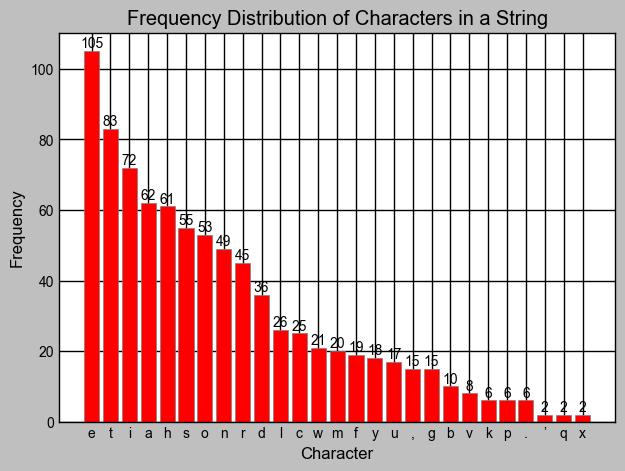

```python
TEXT = "At three o’clock precisely I was at Baker Street, but Holmes had not yet returned. The landlady informed me that he had left the house shortly after eight o’clock in the morning. I sat down beside the fire, however, with the intention of awaiting him, however long he might be. I was already deeply interested in his inquiry, for, though it was surrounded by none of the grim and strange features which were associated with the two crimes which I have already recorded, still, the nature of the case and the exalted station of his client gave it a character of its own. Indeed, apart from the nature of the investigation which my friend had on hand, there was something in his masterly grasp of a situation, and his keen, incisive reasoning, which made it a pleasure to me to study his system of work, and to follow the quick, subtle methods by which he disentangled the most inextricable mysteries. So accustomed was I to his invariable success that the very possibility of his failing had ceased to enter into my head.".lower()

# Remove spaces from the text string for a cleaner bar plot
TEXT_with_no_spaces = TEXT.replace(" ", "")

# Create a dictionary for letter frequency distribution
letter_freq = dict(Counter(TEXT_with_no_spaces))

# Create a variable to sort the dictionary by count descending
sorted_char_count = sorted(letter_freq.items(), key=lambda x: x[1], reverse=True)

# Extract sorted characters and their counts
characters, character_count = zip(*sorted_char_count)

# Plot the X & Y axis
bars = plt.bar(characters, character_count, color='red', edgecolor='grey')

# Labels, titles, and style
plt.style.use('ggplot')
plt.xlabel('Character')
plt.ylabel('Frequency')
plt.title('Frequency Distribution of Characters in a String')

# Display the count above each bar
for bar in bars:
    yval = bar.get_height()  # Get the height (count) of each bar
    plt.text(bar.get_x() + bar.get_width() / 2, yval + 0.1,  # Position the text above the bar
             str(yval), ha='center', va='bottom', fontsize=10, color='black')

plt.show()
```

#### 2. Generate a sequence of at least 5 random numbers (integers are fine), and visualize the data using both `scatter` and `plot` on different axes. You may use the index of the value as its x value in the plot.

##### A. Scatter

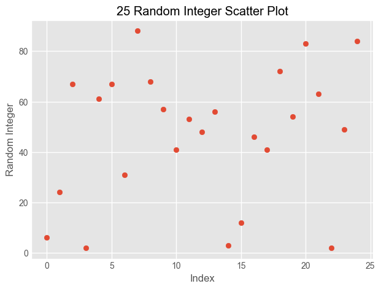

```python
# Generate 25 random numbers
random_numbers = [random.randint(1, 100) for i in range(25)]
random_numbers_index = list(range(len(random_numbers)))

# Create a scatter plot
plt.scatter(random_numbers_index, random_numbers)

# Labels, titles, and style
plt.style.use('ggplot')
plt.title('25 Random Integer Scatter Plot')
plt.xlabel('Index')
plt.ylabel('Random Integer')

plt.show()
```

##### B. Plot

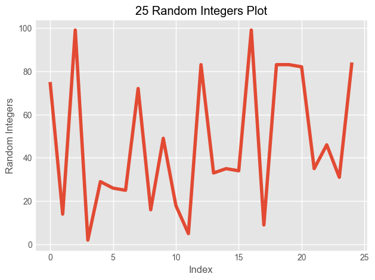

```python
# Generate 5 random integers
random_integers = [random.randint(1, 100) for i in range(25)]
random_integers_index = list(range(len(random_integers)))

# Create a plot
plt.plot(random_integers_index, random_integers)

# Labels, titles, and style
plt.style.use('ggplot')
plt.title('25 Random Integers Plot')
plt.xlabel('Index')
plt.ylabel('Random Integers')

plt.show()
```

#### 3. Do the same question as above, but change the syle and color of both the scatter and the plot.

##### A. Alternative Style Scatter

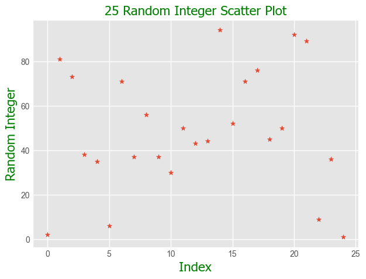

```python
# Generate 25 random numbers
random_numbers = [random.randint(1, 100) for i in range(25)]
random_numbers_index = list(range(len(random_numbers)))

# Create a scatter plot
plt.scatter(random_numbers_index, random_numbers, marker='*')

# Labels, titles, and style
font_properties = {'family': 'tahoma', 'color':  'green', 'weight': 'normal', 'size': 16}
plt.title('25 Random Integer Scatter Plot', fontdict=font_properties)
plt.xlabel('Index', fontdict=font_properties)
plt.ylabel('Random Integer', fontdict=font_properties)

plt.show()
```

##### B. Alternative Style Plot

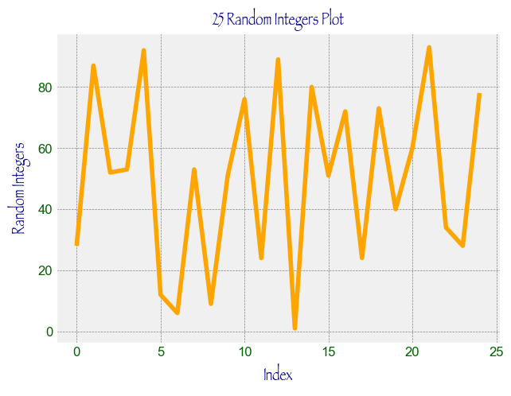

```python
# Generate 5 random integers
random_integers = [random.randint(1, 100) for i in range(25)]
random_integers_index = list(range(len(random_integers)))

# Create a plot
plt.plot(random_integers_index, random_integers,
         color = 'orange')

# Labels, titles, and style
font_properties = {'family': 'papyrus', 'color': 'darkblue', 'weight': 'bold', 'size': 16}
plt.style.use('grayscale')
plt.title('25 Random Integers Plot', fontdict=font_properties)
plt.xlabel('Index', fontdict=font_properties)
plt.ylabel('Random Integers', fontdict=font_properties)

# Grid and background style
plt.grid(True, which='both', linestyle='--', linewidth=0.5, color='gray')
plt.gca().set_facecolor('#f0f0f0')

# Customize the axis ticks
plt.xticks(fontsize=12, color='darkgreen')
plt.yticks(fontsize=12, color='darkgreen')

plt.show()
```

#### 4. Given the data sets below, plot or scatter both on the same set of axes. You are plotting the time it takes to execute a sorting algorithm on a list of a given size; your x axis should be the size, and the y axis is time. Assume that `insertion_sort_times[i]` is how long it took to sort a list of length `sizes[i]`. Add a legend to your plot showing which is insertion sort and which is merge sort. Use the variable names to determine which data is which.

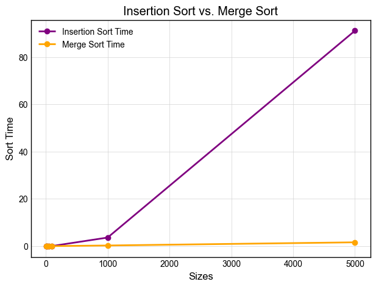

```python
sizes = [10, 20, 50, 100, 1000, 5000]
insertion_sort_times = [0.0010252999999999998, 0.0027026999999999954, 0.010147200000000002, 0.0381137, 3.6303399, 91.2180796]
merge_sort_times = [0.00161889999999687, 0.003635600000009731, 0.0090655000000055, 0.020108000000007564, 0.2687474000000094, 1.6147050999999948]

# Create the plot
plt.plot(sizes, insertion_sort_times, label='Insertion Sort Time', color='purple', linewidth = 2, marker = 'o')
plt.plot(sizes, merge_sort_times, label='Merge Sort Time', color='orange', linewidth = 2, marker = 'o')

# Set the background color of the plot to white
plt.gcf().set_facecolor('white')

# Light grey background for the grid
plt.grid(True, color='lightgrey', linestyle='-', linewidth=0.5)

# Labels, title, and style
plt.xlabel('Sizes')
plt.ylabel('Sort Time')
plt.title('Insertion Sort vs. Merge Sort')
plt.legend()
plt.show()
```